# Analysis of vegetation change in Everglades National Park between 2000 and 2024

[figure not shown]

(Source: National Park Service, https://www.nps.gov/articles/000/everglades-national-park-south-florida.htm)

The Everglades National Park is a vast subtropical wilderness in southern Florida, where freshwater and saltwater habitats merge to form a rich and diverse ecosystem. The park protects the southern approximaltly tewenty percent of the Everglades in Florida, covering an area of approximatly 1.5 million acres of sawgrass marshes, cypress swamps, hardwood hammokcs, pine rocklands, and extensive mangrove forests ([National Park Service, U.S. Department of the Interior](https://www.npshistory.com/publications/ever/brochures/2015.pdf)).

Climate change could significantly alter Everglades National Park in a number of ways. For instance, rising sea levels may flood portions of the park and saltwater intrusion could damage frehwater marshes and distub the balance of ecosystems. In addition, more and intense hurricanes could erode shorelines and damage the ecosystem.

In this analysis, we look at possible changes in the Everglades National Park using the Normalized Difference Vegetation Index ([NDVI](https://www.earthdata.nasa.gov/topics/land-surface/normalized-difference-vegetation-index-ndvi)) The NDVI is a measure used to quantify the density and health of vegetation, and values range from -1 to 1 where low values corresponds to rocks or exposed soil and high values indigates greener vegetation, e.g. forests and wetlands.

### Dataset

For this analysis, we use NDVI data from NASA's Earth satellites ([EARTDATA](https://www.earthdata.nasa.gov/topics/land-surface/normalized-difference-vegetation-index-ndvi)). To extract the data, the Application for Extracting and Exploring Analysis Ready Samples ([AppEEARS](https://appeears.earthdatacloud.nasa.gov/)) offers a simple and efficient way to do this. The period from 2000 to 2024 was selected for the present analysis. The data for the months April to September was extracted so that the time periods could be flexibly changed and compared later in the investigation.

Below you will find the individual elements of the analysis.

```python
# packages
# file structure
import os
import pathlib
import glob
# vector and raster data
import geopandas as gpd
import pandas as pd
import rioxarray as rxr
import xarray as xr
# arrays
import numpy as np
# plotting
import holoviews as hv
import hvplot.pandas
import hvplot.xarray
import matplotlib.pyplot as plt
from sklearn.linear_model import LinearRegression
# open street map
from osmnx import features as osm
import osmnx as ox
# earthpy
import earthpy
import earthpy.api.appeears as eaapp
```

```python
# Set up a project and folder for data using earthpy
project = earthpy.Project("Everglades Vegetation", dirname = 'ndvi_project')
```

OSMnx is a Python package to easily download, model, analyze, and visualize street networks and other geospatial features from OpenStreetMap. `ox.geocode_to_gdf()` returns the boundaries as a GeoDataFrame.

```python
# Search for Everglades Natironal Park using OpenStreetMaps
everglades_gdf = ox.geocode_to_gdf(
    'Everglades National Park')

# Check it out
everglades_gdf
```

|  | geometry | bbox_west | bbox_south | bbox_east | bbox_north | place_id | osm_type | osm_id | lat | lon | class | type | place_rank | importance | addresstype | name | display_name |
| --- | --- | --- | --- | --- | --- | --- | --- | --- | --- | --- | --- | --- | --- | --- | --- | --- | --- |
| 0 | POLYGON ((-81.52053 25.83264, -81.52048 25.818... | -81.520526 | 24.851129 | -80.388994 | 25.891513 | 416088476 | relation | 2163707 | 25.367944 | -80.878307 | boundary | protected_area | 25 | 0.540428 | protected_area | Everglades National Park | Everglades National Park, Florida, 34138, Unit... |

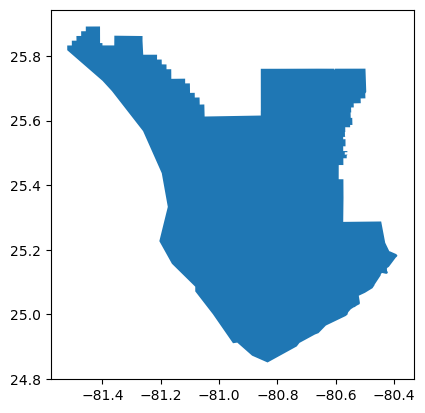

```python
# Make a plot of the boundary
everglades_gdf.plot()
```

Retrieve NDVI data from 2000 to 2024 for the selected area

```python
# Initialize AppeearsDownloader for MODIS NDVI data
# Set parameters
ndvi_downloader = eaapp.AppeearsDownloader(

    # Give the download a name
    download_key = "everglades_ndvi",

    # Tell it to put the data in the project directory already defined
    project = project,

    # Specify the MODIS product
    product = 'MOD13Q1.061',
    layer = '_250m_16_days_NDVI',

    # Set a start date and end data
    start_date = "04-01",
    end_date = "09-30",

    # Recurring meaning we want to download those dates over multiple years
    recurring = True,

    # Specify the range of years of interest
    year_range = [2000, 2024],

    # Specify the polygon we want to get NDVI data for
    polygon = everglades_gdf
)
```

```python
# Download the prepared download
ndvi_downloader.download_files(cache=True)
```

```
<generator object Path.rglob at 0x7053755daf00>
```

```python
# Get a sorted list of NDVI file paths
ndvi_paths = sorted(list(project.project_dir.rglob('*NDVI*.tif')))

# View the paths
#ndvi_paths
```

Map of the Everglades National Park border with an ESRI satellite image as background. Here you can nicely see the different ecoregions of the park.

```python
everglades_contour = everglades_gdf.hvplot(
    geo=True, tiles='EsriImagery',
    frame_width=500,
    legend=False,
    fill_color=None,
    line_color='white',
    title='Everglades National Park',
    )

# hv.save(everglades_contour, 'everglades_satellite.html')
everglades_contour
```

[output not shown]

Previously, we had a series of individual files, which were more complex to use, especially when searching for time periods or creating time averages. To simplify the work with the NDVI data, we first convert the data into DataArrays and stack the array by time using stack arrays by date using the `xr.combine_by_coords()` function.

```python
doy_start = -25         # -25 to -22 is the year
doy_end = -18           # -21 to -19 is the day of the year

# Loop through each NDVI image
ndvi_das = []
for ndvi_path in ndvi_paths:

    # Get date from file name
    doy = ndvi_path.name[doy_start:doy_end]
    # doy is a string of year + day of the year
    date = pd.to_datetime(doy, format="%Y%j")
    # Open dataset

    data = rxr.open_rasterio(ndvi_path, mask_and_scale=True).squeeze()

    # Add date dimension and clean up metadata
    data = data.assign_coords({'date': date})
    data = data.expand_dims({'date': 1})
    data.name = 'NDVI'

    # Prepare for concatenation
    ndvi_das.append(data)
```

```python
# Combine NDVI images from all dates
ndvi_da = xr.combine_by_coords(ndvi_das, coords = ['date'])
ndvi_da
```

```
<xarray.Dataset> Size: 354MB
Dimensions:      (date: 325, y: 500, x: 544)
Coordinates:
    band         int64 8B 1
  * x            (x) float64 4kB -81.52 -81.52 -81.52 ... -80.39 -80.39 -80.39
  * y            (y) float64 4kB 25.89 25.89 25.89 25.88 ... 24.86 24.85 24.85
    spatial_ref  int64 8B 0
  * date         (date) datetime64[ns] 3kB 2000-03-21 2000-04-06 ... 2024-09-29
Data variables:
    NDVI         (date, y, x) float32 354MB 0.5234 0.1257 0.1257 ... nan nan nan
```

### First Plots

First, we compare an NDVI image from the earliest year of records with the latest year of records. To enable a better comparison, we select the same day of the year for each year.

```python
print(ndvi_paths[5])
print(ndvi_paths[-8])
```

[output not shown]

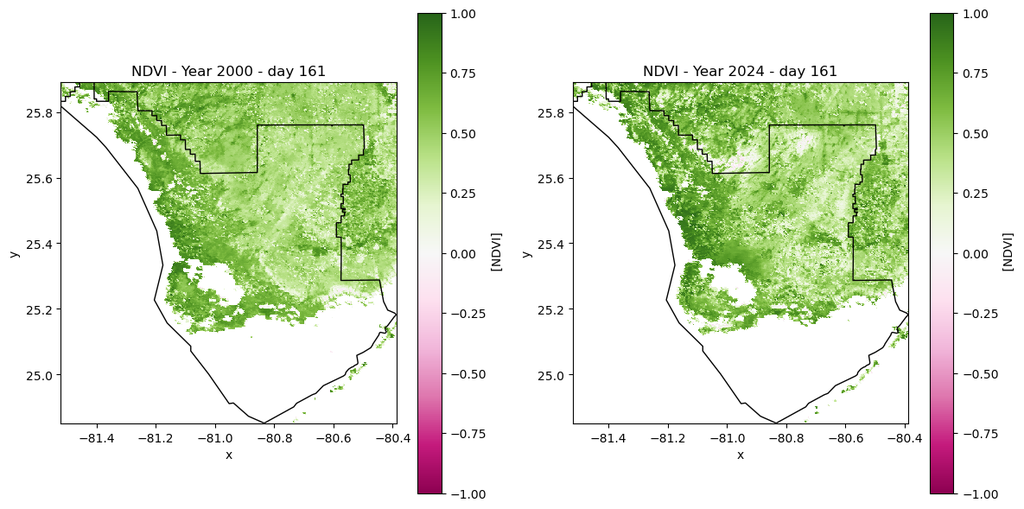

```python
# plot them side by side
ndvi_first = rxr.open_rasterio(ndvi_paths[5], mask_and_scale = True).squeeze()
ndvi_last = rxr.open_rasterio(ndvi_paths[-8], mask_and_scale = True).squeeze()

# make side by side subplots
# 1 subplot with 1 row + 2 columns
fig, axes = plt.subplots(1, 2, figsize=(12, 6))

# plot first ndvi with gila river boundary
ndvi_first.plot(ax=axes[0], cmap=plt.cm.PiYG, vmin=-1, vmax=1)
everglades_gdf.plot(ax=axes[0], edgecolor='black', facecolor='none', linewidth=1)
axes[0].set_title("NDVI - Year 2000 - day 161")

# plot last ndvi with gila river boundary
ndvi_last.plot(ax=axes[1], cmap=plt.cm.PiYG, vmin=-1, vmax=1)
everglades_gdf.plot(ax=axes[1], edgecolor='black', facecolor='none', linewidth=1)
axes[1].set_title("NDVI - Year 2024 - day 161")

# play with layout
plt.tight_layout()
plt.show()
```

### Clacualte and plot difference maps

[figure not shown]

(Source: NOAA, https://www.nhc.noaa.gov/climo/)

```python
# ndvi_da_annual = ndvi_da.groupby('date.year').mean()
september_data = ndvi_da.sel(date=ndvi_da.date.dt.month == 9)
```

```python
#ndvi_data_2000_2012 = ndvi_da_annual.sel(year=slice('2000', '2012')).mean('year').NDVI
#ndvi_data_2013_2024 = ndvi_da_annual.sel(year=slice('2013', '2024')).mean('year').NDVI

ndvi_data_2000_2012 = september_data.sel(date=slice('2000', '2012')).mean('date').NDVI
ndvi_data_2013_2024 = september_data.sel(date=slice('2013', '2024')).mean('date').NDVI
```

```python
# Compute the difference in NDVI before and after
ndvi_diff = (
    ndvi_data_2013_2024
    -
    ndvi_data_2000_2012
)


# Plot the difference
diff_plot = (
    ndvi_diff.hvplot(x='x', y='y', cmap='PiYG', geo=True,
                     title = "NDVI changes in Everglades National Park\nfrom 2000-2012 to 2013-2024")
    *
    everglades_gdf.hvplot(geo=True, fill_color=None, line_color='black')
)

#hv.save(diff_plot, 'everglades_diff.html')
diff_plot
```

[output not shown]

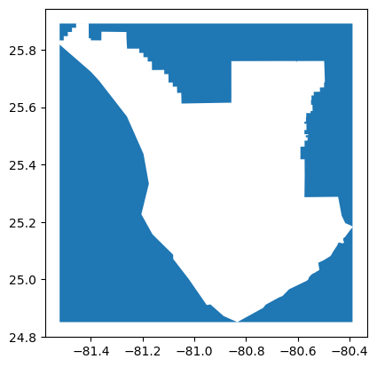

```python
# Compute the area outside the Gila River Indian Community
non_everglades_gdf = (
    gpd.GeoDataFrame(geometry=everglades_gdf.envelope)
    .overlay(everglades_gdf, how='difference')
)

# Plot the outside Gila gdf
non_everglades_gdf.plot()
```

```python
# Clip data to inside the boundary
ndvi_inside = september_data.rio.clip(everglades_gdf.geometry, from_disk=True)
ndvi_inside

# Clip data to outside the boundary
ndvi_outside = september_data.rio.clip(non_everglades_gdf.geometry, from_disk=True)
ndvi_outside
```

```
<xarray.Dataset> Size: 54MB
Dimensions:      (x: 543, y: 499, date: 50)
Coordinates:
    band         int64 8B 1
  * x            (x) float64 4kB -81.52 -81.52 -81.52 ... -80.39 -80.39 -80.39
  * y            (y) float64 4kB 25.89 25.89 25.89 25.88 ... 24.86 24.86 24.85
  * date         (date) datetime64[ns] 400B 2000-09-13 2000-09-29 ... 2024-09-29
    spatial_ref  int64 8B 0
Data variables:
    NDVI         (date, y, x) float32 54MB 0.3694 0.395 0.5093 ... nan nan nan
```

```python
# Compute mean annual July NDVI
# inside
september_ndvi_inside_df = (ndvi_inside
                       .groupby(ndvi_inside.date.dt.year) # group by year
                       .mean(...) # get mean NDVI
                       .NDVI
                       .to_dataframe()) # convert data to a dataframe
september_ndvi_inside_df.head()

# outside
september_ndvi_outside_df = (ndvi_outside
                       .groupby(ndvi_inside.date.dt.year) # group by year
                       .mean(...) # get mean NDVI
                       .NDVI
                       .to_dataframe()) # convert data to a dataframe
september_ndvi_outside_df.head()
```

| year | band | spatial_ref | NDVI |
| --- | --- | --- | --- |
| 2000 | 1 | 0 | 0.490089 |
| 2001 | 1 | 0 | 0.479307 |
| 2002 | 1 | 0 | 0.480867 |
| 2003 | 1 | 0 | 0.455129 |
| 2004 | 1 | 0 | 0.474608 |

```python
# Join inside and outside DataFrames and rename/add suffix to column names
september_ndvi_df = (
            september_ndvi_inside_df[['NDVI']]           # NDVI data from for the first DataFrame
            .join(september_ndvi_outside_df[['NDVI']],   # NDVI from the second DataFrame
            lsuffix='_inside',                      # rename first
            rsuffix='_outside'))                    # rename second
september_ndvi_df
```

| year | NDVI_inside | NDVI_outside |
| --- | --- | --- |
| 2000 | 0.552312 | 0.490089 |
| 2001 | 0.544355 | 0.479307 |
| 2002 | 0.547538 | 0.480867 |
| 2003 | 0.524635 | 0.455129 |
| 2004 | 0.539335 | 0.474608 |
| 2005 | 0.502442 | 0.471116 |
| 2006 | 0.569655 | 0.507923 |
| 2007 | 0.538182 | 0.473243 |
| 2008 | 0.512235 | 0.456622 |
| 2009 | 0.515483 | 0.464680 |
| 2010 | 0.505016 | 0.462307 |
| 2011 | 0.548476 | 0.518178 |
| 2012 | 0.496987 | 0.459010 |
| 2013 | 0.536285 | 0.475081 |
| 2014 | 0.528398 | 0.467146 |
| 2015 | 0.545905 | 0.476658 |
| 2016 | 0.553078 | 0.485679 |
| 2017 | 0.454297 | 0.449577 |
| 2018 | 0.517451 | 0.483359 |
| 2019 | 0.556171 | 0.516240 |
| 2020 | 0.539087 | 0.491989 |
| 2021 | 0.541199 | 0.480465 |
| 2022 | 0.572482 | 0.522705 |
| 2023 | 0.559325 | 0.492034 |
| 2024 | 0.562163 | 0.518127 |

```python
### calculate the difference
september_ndvi_df['difference'] = (september_ndvi_df['NDVI_inside']
                              - september_ndvi_df['NDVI_outside'])

september_ndvi_df[["NDVI_inside", "NDVI_outside"]]
```

| year | NDVI_inside | NDVI_outside |
| --- | --- | --- |
| 2000 | 0.552312 | 0.490089 |
| 2001 | 0.544355 | 0.479307 |
| 2002 | 0.547538 | 0.480867 |
| 2003 | 0.524635 | 0.455129 |
| 2004 | 0.539335 | 0.474608 |
| 2005 | 0.502442 | 0.471116 |
| 2006 | 0.569655 | 0.507923 |
| 2007 | 0.538182 | 0.473243 |
| 2008 | 0.512235 | 0.456622 |
| 2009 | 0.515483 | 0.464680 |
| 2010 | 0.505016 | 0.462307 |
| 2011 | 0.548476 | 0.518178 |
| 2012 | 0.496987 | 0.459010 |
| 2013 | 0.536285 | 0.475081 |
| 2014 | 0.528398 | 0.467146 |
| 2015 | 0.545905 | 0.476658 |
| 2016 | 0.553078 | 0.485679 |
| 2017 | 0.454297 | 0.449577 |
| 2018 | 0.517451 | 0.483359 |
| 2019 | 0.556171 | 0.516240 |
| 2020 | 0.539087 | 0.491989 |
| 2021 | 0.541199 | 0.480465 |
| 2022 | 0.572482 | 0.522705 |
| 2023 | 0.559325 | 0.492034 |
| 2024 | 0.562163 | 0.518127 |

```python
# Plot mean NDVI inside and outside the boundary
everglades_in_out = september_ndvi_df[["NDVI_inside", "NDVI_outside"]].hvplot(title = "Mean September NDVI inside and outside GRIC")
# hv.save(everglades_in_out, 'everglades_in_out.html')
everglades_in_out
```

[output not shown]

```python
# Plot mean NDVI difference
everglades_in_out_diff = september_ndvi_df[["difference"]].hvplot(title = "Mean September NDVI inside and outside GRIC")
# hv.save(everglades_in_out_diff, 'everglades_in_out_diff.html')
everglades_in_out_diff
```

[output not shown]

## No clear NDVI trend, but outliers in individual years

Based on the Normalized Difference Vegetation Index (NDVI), we looked at Everglades National Park and how the vegetation has changed between 2000 and 2024. The focus was placed on the month of September, following the hottest days of summer and the peak season for tropical storms and hurricanes.

A split of the time series and comparison of the periods 2000 to 2012 and 2013 to 2024 shows that coastal areas and areas adjacent to urban and metropolitan areas of the national park in particular show a decrease in NDVI, while central areas of the park show an increase in NDVI.

The Everglades are extremely low-lying. Thus, even small increase in sea level have a big effect. Saltwater intrusion pushes saltwater farther into freshwater marshes withy the pontential to kill frehswater vegetation. Rising sea levels can also lead to rising groundwater levels in this area, resulting in increased vegetation in the center of the national park.

Looking at the time series, no strong trend is apparent within the time frame of this analysis (perhaps only slightly in the second half). A comparison of the NDVI outside and inside the national park shows higher values inside the park. This is also due to the fact that there is an urban area adjacent to the national park.

When looking at the difference between outside and inside the park, it is interesting to note that there are three years (2005, 2011, and 2017) where the difference is substantial smaller, one of which is particularly pronounced (2017). The year 2017 in particular show a more drastic reduction in the difference compared to the previous and following years. In that year, the hurricane Irma striked the Everglades. Hurricane Irma was a particularly strong and long-lasting event that made landfall as a Category 4 storm on September 10 and then moved northward through Florida and Georgia and did extensive damage to the forest canopy ([USGS](https://www.usgs.gov/special-topics/lcmap/science/lcmap-change-stories-hurricanes-everglades)). The follwing shows the infrared satellite loop from September 10th, 2017, where hurricane Irma hits the Everglades National Park.

[figure not shown]

(Source: NOAA weater service, https://www.weather.gov/mfl/hurricaneirma)